# Bayesovská analýza - Gamma-Poisson model

Cvičení 5.5 a 5.6: Analýza početnosti textových správ

Dana Kozáková

2025-10-22

## Úvod

Tento dokument obsahuje riešenie cvičení 5.5 a 5.6 z knihy [Bayes Rules!](https://www.bayesrulesbook.com/chapter-5#exercises-4) Modelovanie rýchlosti príjmu textových správ za hodinu pomocou Gamma-Poisson modelu. Najprv apriórna informácia, potom dáta. Následne posteriórny model.

**Zdroj:**

- [Bayes Rules! - Kapitola 5](https://www.bayesrulesbook.com/chapter-5#exercises-4)

## Exercise 5.5: Nastavenie priorného modelu

### Zadanie

> Nech náhodná premenná $\lambda$ predstavuje počet textových správ, ktoré ľudia dostanú za hodinu. Najprv, predpokladaj, že typický počet správ za hodinu je 5 so štandardnou odchýlkou 0,25 správ.
> 1. Vylaď a zobraz graficky vhodný Gamma($s$,$r$) apriórny model pre $\lambda$.
> 2. Aká je pravdepodobnosť, že počet textových správ za hodinu je véčší ako 10? (Nápoveda: pozri $pgamma()$)

### Riešenie:

Náhodná premenná $\lambda$ reprezentuje rýchlosť príjmu textových správ za hodinu. Predpokladáme, že typický počet správ za hodinu je 5 so smerodajnou odchýlkou 0,25 správ.

Pre modelovanie premennej $\lambda$ sú vhodné modely: *F*, *Weibull* alebo *Gamma*. Aby bola konštrukcia posterior modelu jednoduchá a priama, využijeme konjugovaný Gamma model.

### a) Nastavenie priorného modelu Gamma pre modelovanie hodnoty $\lambda$

*Poznámka: iba v rámci Poissonovho modelu platí, že stredná hodnota sa rovná rozptylu.*

**Z požiadavky v zadaní:**

- Stredná hodnota E() = 5
- Smerodajná odchýlka SD() = 0,25
- Rozptyl Var() = 0,25² = 0,0625

> **Pre Gamma rozdelenie platí:**
> $$\begin{equation}
> \begin{split}
> E(\lambda) & = \frac{s}{r} \\
> \text{Var}(\lambda) & = \frac{s}{r^2} \\
> \end{split}
> \tag{E & Var for Gamma}
> \end{equation}$$

> **Z toho vyplýva:**
> $$\begin{equation}
> \begin{split}
> \frac{s}{r} = 5 ---> s & = 5 * r\\
> \frac{s}{r^2} = 0,0625 --> s & = 0.0625 * r^2\\
> 5 * r & = 0.0625 * r^2 \\
> \frac{5}{0.0625} & = r \\
> r & = 80 \\
> s & = 5 *80 \\
> \end{split}
> \end{equation}$$

> **Všeobecne:**
> - je dané E($\lambda$) a Var($\lambda$)
> $$\begin{equation}
> \begin{split}
> \frac{s}{r} = E ---> s & = E * r\\
> \frac{s}{r^2} = Var --> s & = Var * r^2\\
> E * r & = Var * r^2 \\
> \frac{E}{Var} * r & = r^2 \\
> r & = \frac{E}{Var} \\
> s & = E * r \\
> \end{split}
> \end{equation}$$

```r
# Parametre priorného modelu

E <- 5
SD <- 0.25
Var <- SD^2

r <- E/Var
s <- E*r

cat ('Gamma model má parametre: Gamma(', s, ', ', r, ')', '\n', sep = "")
```

```
## Gamma model má parametre: Gamma(400, 80)
```

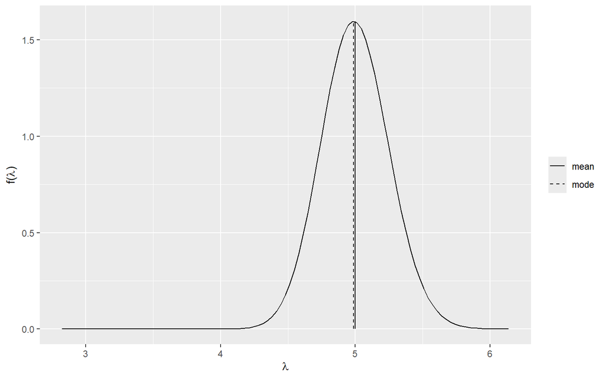

```r
# Gamma model v grafe
plot_gamma(shape = s, rate = r, mean = TRUE, mode = TRUE)
```

```r
# Číselné charakteristiky pre Gamma model
summarize_gamma(s, r)
```

```
##   mean   mode    var   sd
## 1    5 4.9875 0.0625 0.25
```

Tu vidíme, že model má skutočne strednú hodnotu požadovaných 5 správ a odchýlku 0,25. Modus sa nerovná mediánu, nie je to presne symetrické rozdelenie.

### b) Pravdepodobnosť, P($\lambda$ > 10)

Pravdepodobnosť, že v tomto apriornom modeli bude mať viac ako 10 správ

```r
# Pravdepodobnosť, že λ > 10
prob_greater_10 <- pgamma(10, shape = s, rate = r, lower.tail = FALSE)
cat('Pravdepodobnosť viac ako 10 správ za hodinu:',prob_greater_10, '\n')
```

```
## Pravdepodobnosť viac ako 10 správ za hodinu: 9.813974e-56
```

Apriorná pravdepodobnosť, že počet správ presiahne 10 za hodinu, je 9.813974e-56, co je extrémne nízka hodnota.

```r
# "Kontrola" symetrie
lg <- pgamma(5, shape = s, rate = r, lower.tail = FALSE)
pg <- pgamma(5, shape = s, rate = r, lower.tail = TRUE)

cat('Pravdepodobnosť - naľavo od strednej hodnoty:', lg, ',', 'napravo od strednej hodnoty:', pg)
```

```
## Pravdepodobnosť - naľavo od strednej hodnoty: 0.4933509 , napravo od strednej hodnoty: 0.5066491
```

## Cvičenie 5.6: Aktualizácia prior modelu dátami

### Zadanie

> Zozbierali sme dáta od 6 priateľov. Dostali nasledujúci počet správ za poslednú hodinu: 7, 3, 8, 9, 10, 12.
> 1. Vykresliť vierohodnostnú funkciu $\lambda$.
> 2. Vykresliť priorné pdf, vierohodnostnú funkciu a posteriorné pdf $\lambda$.
> 3. Použiť `summarize_gamma_poisson()` pre výpočet deskriptívnych štatistík.
> 4. Komentovať, ako sa zmenilo naše porozumenie λ od prioru k posterioru

### Riešenie:

### Dátový model

```r
# Naše dáta
y <- c(7, 3, 8, 9, 10, 12)
```

### a) Vierohodnostná funkcia pre $\lambda$

> Neznámy hyperparameter $\lambda$ má Gamma rozdelenie.
> $$\begin{split}
> \lambda & \sim \text{Gamma}(s, r) .\\
> \end{split}$$

> Za predpokladu, že poznáme $\lambda$, tak počet správ za hodinu modelujeme Poissonovým rozdelením. T.j. vierohodnostná funkcia je:
> $$\begin{split}
> Y | \lambda & {\sim} \text{Pois}(\lambda) \\
> \end{split}$$

> Označme ($Y_1$,$Y_2$,,$Y_n$) počet správ v jednotlivých hodinách, od prvej hodiny po $n$.-tú. Počet za jednu hodinu sa može meniť, je **nezávisle** modelovaný Poissonovým modelom.

> $$\begin{split}
> Y_i | \lambda & \stackrel{ind}{\sim} \text{Pois}(\lambda) \\
> \end{split}$$

> Funkcia hustoty pre toto jedno pozorovanie:
> $$\begin{split}
> f(y_i|\lambda) = \frac{\lambda^{y_i}e^{-\lambda}}{y_i!}\;\; \text{ for
> } y_i \in \{0,1,2,\ldots\}
> \end{split}$$

> Neanalyzujeme však každý deň samostatne, využijeme súhrnnú informáciu zo všetkých dní, t.j. máme funkciu združenej hustoty pravdepodobnosti:  
> **Združená hustota pravdepodobnosti**
> - Nech $(Y_1,Y_2,\ldots,Y_n)$ sú nezávislé pozorovania náhodnej premennej a $\vec{y} = (y_1,y_2,\ldots,y_n)$ je vektor týchto pozorovaní
> - $f(y_i | \lambda)$ označuje funkciu hustoty pre jedno pozorovanie $Y_i$.

> Za predpokladu nezávislosti potom možeme napísať združenú funkciu hustoty pre vektor zistených dát:
> $$\begin{equation}
> f(\vec{y} | \lambda) = \prod_{i=1}^n f(y_i | \lambda) = f(y_1 | \lambda)
> \cdot f(y_2 | \lambda) \cdot \cdots \cdot f(y_n | \lambda) .
> \tag{Joint pmf}
> \end{equation}$$
> Po dosadení vyjadrenia hustoty pre Poissonovo rozdelenie dostávame:
> $$\begin{split}
> f(\vec{y} | \lambda)
> & = \frac{\lambda^{y_1}e^{-\lambda}}{y_1!} \cdot
> \frac{\lambda^{y_2}e^{-\lambda}}{y_2!} \cdots
> \frac{\lambda^{y_n}e^{-\lambda}}{y_n!} \\
> & = \frac{\left[\lambda^{y_1}\lambda^{y_2} \cdots
> \lambda^{y_n}\right] \left[e^{-\lambda}e^{-\lambda} \cdots
> e^{-\lambda}\right]}{y_1! y_2! \cdots y_n!} \\
> & =\frac{\lambda^{\sum y_i}e^{-n\lambda}}{\prod_{i=1}^n y_i!} \\
> \end{split}$$

> Teda máme vierohodnostnú funkciu pre $\lambda$ (tá je rovnaká ako združená hustota, líši sa len pochopením parametra)
> $$\begin{equation}
> L(\lambda | \vec{y}) = \frac{\lambda^{\sum
> y_i}e^{-n\lambda}}{\prod_{i=1}^n y_i!} \propto \lambda^{\sum
> y_i}e^{-n\lambda} \;\; \text{ for } \lambda > 0.
> \tag{likehood}
> \end{equation}$$

#### Graf pre vierohodnostnú funkciu (likehood)

Tento graf zobrazuje pravdepodobnosť získaných dát za predpokladu, že by parameter $\lambda$ bol postupne z intervalu [0; 20]

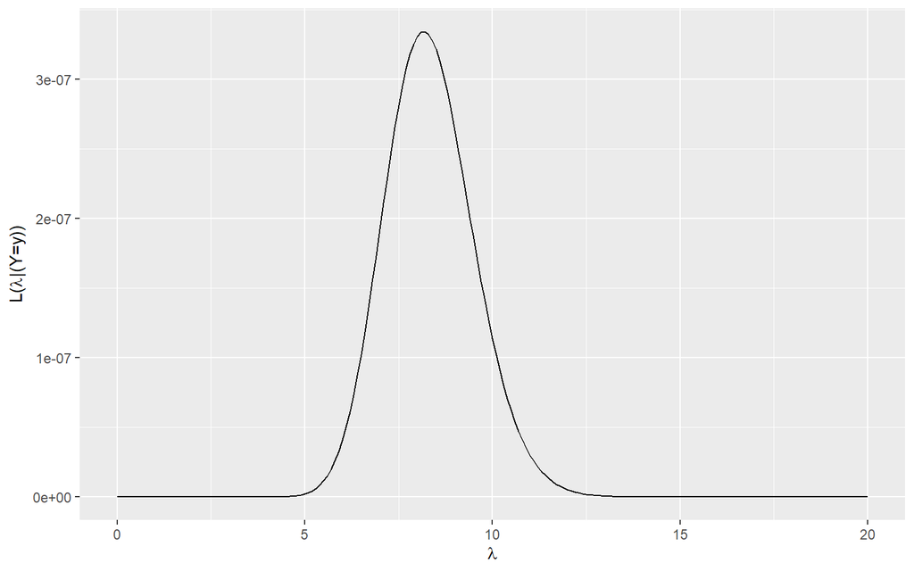

```r
# Vierohodnostná funkcia
plot_poisson_likelihood(y = y, lambda_upper_bound = 20) # 20 je odhad vzhladom na data, hranica 10 je malo
```

### b) Vykresliť priorné pdf, vierohodnostnú funkciu a posteriorné pdf pre $\lambda$

**Posteriorný model** Posteriorny model je proporcionálny súčinu apriorneho modelu a vierohodnostného modelu:

> Na začiatku apriórny model, ktorý má Gamma rozdelenie:
> $$\begin{split}
> \lambda & \sim \text{Gamma}(s, r) .\\
> \end{split}$$

> Jednotlivé pozorovania majú Poissonovo rozdelenie:
> $$\begin{split}
> Y_i | \lambda & \stackrel{ind}{\sim} \text{Pois}(\lambda) \\
> \end{split}$$

> Na základe apriórneho modelu a pozorovania dát –> posteriórny Gamma model:  
> $f(\lambda|\vec{y}) \propto f(\lambda)L(\lambda|\vec{y}) = \frac{r^s}{\Gamma(s)} \lambda^{s-1} e^{-r\lambda} \cdot \frac{\lambda^{\sum y_i}e^{-n\lambda}}{\prod y_i!} \;\;\; \text{ for } \lambda > 0.$

> Možeme vynechať konštanty (zaujíma nás len proporcionalita):
> $$\begin{split}
> f(\lambda|\vec{y})
> & \propto \lambda^{s-1} e^{-r\lambda} \cdot \lambda^{\sum
> y_i}e^{-n\lambda} \\
> & = \lambda^{s + \sum y_i - 1} e^{-(r+n)\lambda} \\
> \end{split}$$

> Vidíme, že $\lambda$ je umocnená na ${s + \sum y_i - 1}$ a $e$ je umocnené na ${-(r+n)\lambda}$, čo odpovedá parametrom Gamma modelu:
> $$\begin{equation}
> \lambda|\vec{y} \; \sim \; \text{Gamma}\left(s + \sum y_i, \; r +
> n\right) .
> \tag{posterior}
> \end{equation}$$

#### Graf pre apriórný, vierohodnostný aj posteriórny model

V grafe vidíme rozdelenia všetkých troch modelov.

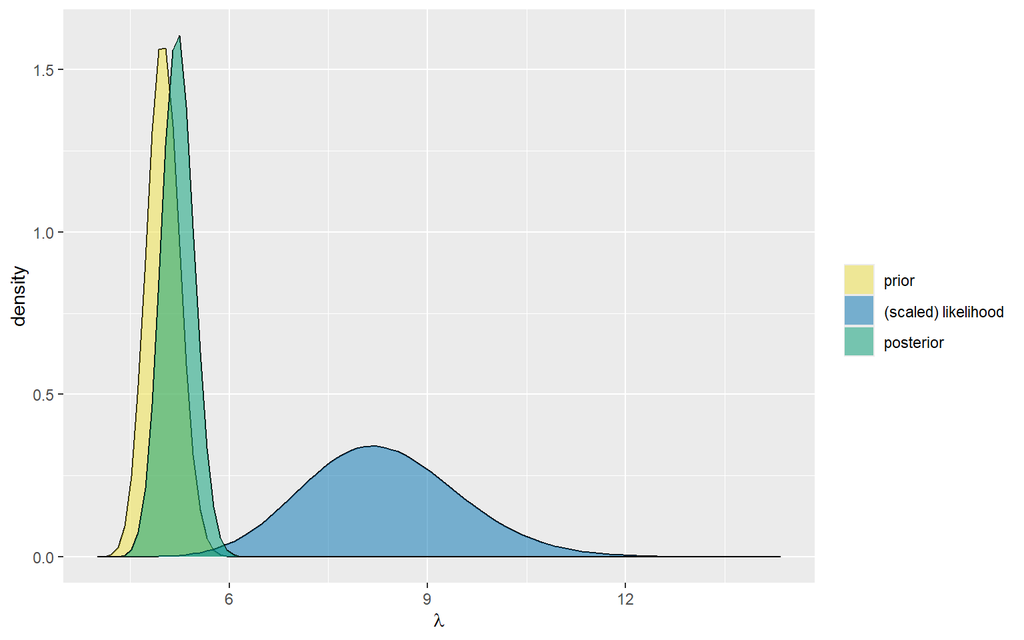

```r
# Zobrazenie prioru, vierohodnosti a posterioru
plot_gamma_poisson(shape = s, rate = r, sum_y = sum(y), n = length(y))
```

Vidíme, že postreriórny model je váženým priemerom apriórneho a vierohodnostného modelu.

**Porovnanie prior vs. posterior** Porovnanie charakteristík apriórneho a posteriórneho Gamma modelu

```r
# Porovnanie charakteristík
comparison <- summarize_gamma_poisson(shape = s, rate = r,
                                      sum_y = sum(y), n = length(y))
comparison
```

```
##       model shape rate    mean     mode        var        sd
## 1     prior   400   80 5.00000 4.987500 0.06250000 0.2500000
## 2 posterior   449   86 5.22093 5.209302 0.06070849 0.2463909
```

**Interpretácia:** Získané dáta od priateľov posunuli naše presvedčenie o priemernej rýchlosti správ z pôvodných 5 správ/hodinu smerom k vyššiemu počtu, k priemeru 5,22. Posun je len veľmi mierny.

### Len posteriorný model

Ak chceme detailne pozrieť rozdelenie pre posteriórny model, zobrazíme ho ako apriórny so zmenenými charakteristikami podľa vzťahu pre (posterior).

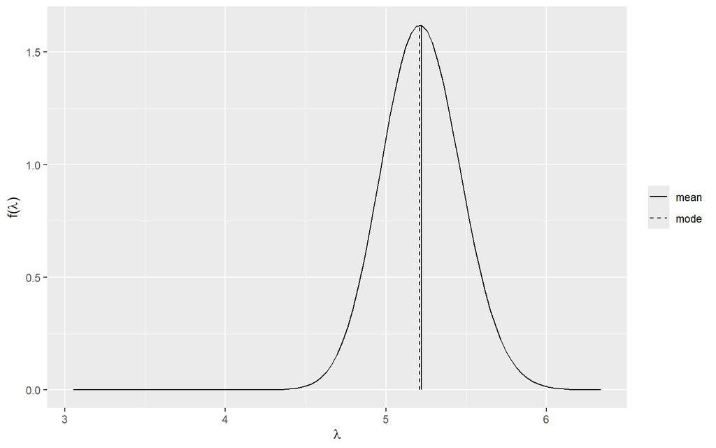

```r
# Vizualizácia posteriorného modelu
plot_gamma(shape = s + sum(y), rate = r + length(y), mean = TRUE, mode = TRUE)
```

```r
# Charakteristiky posterioru
summarize_gamma(s + sum(y), r + length(y))
```

```
##      mean     mode        var        sd
## 1 5.22093 5.209302 0.06070849 0.2463909
```

## Sekvenčné učenie: Druhá vlna dát

Ak prídu ďalšie dáata, pokračujeme v učení s ďalšími dátami. Posterior z predošlej analýzy sa stáva novým priorom.

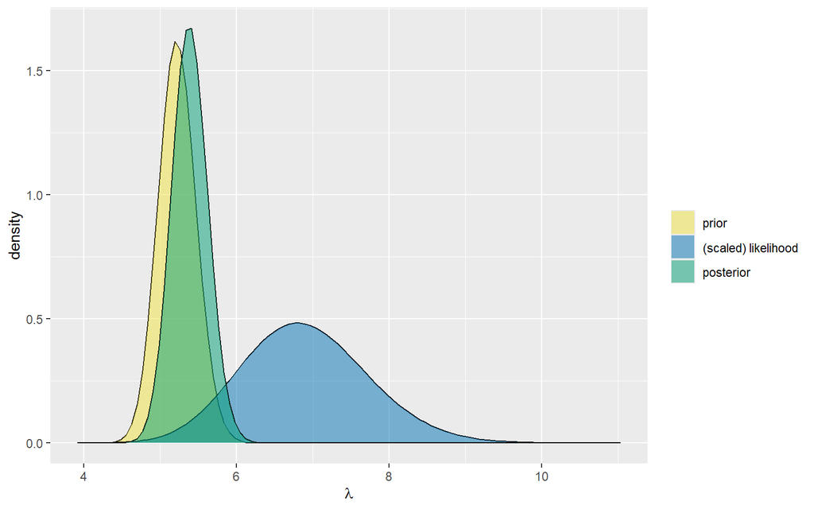

```r
# Uloženie prvého modelu
mod_1 <- summarize_gamma_poisson(shape = s, rate = r,
                                 sum_y = sum(y), n = length(y))

# Nové dáta
y2 <- c(6, 4, 10, 12, 1, 0, 5, 9, 13, 8)

# Posterior z mod_1 sa stáva priorom pre mod_2
s_2 <- mod_1$shape[2]  # Posteriorný shape
r_2 <- mod_1$rate[2]   # Posteriorný rate

# Aktualizácia s novými dátami
plot_gamma_poisson(shape = s_2, rate = r_2,
                   sum_y = sum(y2), n = length(y2))
```

```r
# Nový model
mod_2 <- summarize_gamma_poisson(shape = s_2, rate = r_2,
                                 sum_y = sum(y2), n = length(y2))
mod_2
```

```
##       model shape rate     mean     mode        var        sd
## 1     prior   449   86 5.220930 5.209302 0.06070849 0.2463909
## 2 posterior   517   96 5.385417 5.375000 0.05609809 0.2368504
```

Znova sa naša predstava o parametri $\lambda$ posunula vyššie na základe ďalších dát.

## Záver

Pomocou bayesovského prístupu:

1. Nastavenie apriórneho modelu
2. Aktualizácia reálnymi dátami
3. Demonštrácia sekvenčného učenie s ďalšími pozorovaniami

Bayesovský prístup nám umožňuje priebežne aktualizovať naše presvedčenie s príchodom nových dát. Pri príchode ďalších dát, nezáleží na ich poradí, ani na tom, či prichádzajú postupne alebo sumárne v skupine.

*Poznámka: Pre ďalšie typy modelov pozri [Bayes Rules Book](https://www.bayesrulesbook.com/chapter-5#exercises-4)*